# BayesianFinal

```python
! pip install pymc
```

```python
import os
import glob
import pickle
import numpy as np
import pandas as pd
import librosa
import torch
import pymc as pm
import pytensor.tensor as pt
import arviz as az
import matplotlib.pyplot as plt
from sklearn.metrics import accuracy_score
from transformers import Wav2Vec2Processor, Wav2Vec2Model
```

```python
from transformers import pipeline
from huggingface_hub import login

# Authenticate with your token
login("token")

# Load the private model
pipe = pipeline("automatic-speech-recognition", model="kehanlu/mandarin-wav2vec2-aishell1", token=True)
```

```
Some weights of Wav2Vec2ForCTC were not initialized from the model checkpoint at kehanlu/mandarin-wav2vec2-aishell1 and are newly initialized: ['lm_head.bias', 'lm_head.weight']
You should probably TRAIN this model on a down-stream task to be able to use it for predictions and inference.
Hardware accelerator e.g. GPU is available in the environment, but no `device` argument is passed to the `Pipeline` object. Model will be on CPU.
```

```python
# Initialize the pre-trained Mandarin Wav2Vec2 model and processor
processor = Wav2Vec2Processor.from_pretrained("kehanlu/mandarin-wav2vec2")
model = Wav2Vec2Model.from_pretrained("kehanlu/mandarin-wav2vec2")
model.eval()
```

[output not shown]

```python
def load_audio(file_path, target_sr=16000):
    audio, sr = librosa.load(file_path, sr=None, mono=True)
    if sr != target_sr:
        audio = librosa.resample(audio, orig_sr=sr, target_sr=target_sr)
    audio, _ = librosa.effects.trim(audio)
    return audio, target_sr

def extract_audio_embedding(audio, sr):
    input_values = processor(audio, sampling_rate=sr, return_tensors="pt").input_values
    with torch.no_grad():
        outputs = model(input_values)
    # Average over time dimension to get a fixed-length embedding
    mean_embedding = outputs.last_hidden_state.mean(dim=1).squeeze().numpy()
    return mean_embedding

def load_subject_all_embeddings(subject_dir):
    """
    For a given subject folder, load each of the 29 recordings separately
    and extract its embedding.
    Returns a dictionary mapping recording number (str) to embedding.
    """
    embeddings = {}
    for file in glob.glob(os.path.join(subject_dir, "*.wav")):
        # Extract recording number from file name (e.g., "1.wav" becomes "1")
        recording_number = os.path.splitext(os.path.basename(file))[0]
        try:
            audio, sr = load_audio(file, target_sr=16000)
            emb = extract_audio_embedding(audio, sr)
            embeddings[recording_number] = emb
        except Exception as e:
            print(f"Error processing {file}: {e}")
    return embeddings

def load_all_subject_embeddings(base_audio_dir, subject_id_ignore=["02010004"], output_file="subject_embeddings.pkl"):
    """
    Loads embeddings for all subjects (ignoring certain subject ids with contaminated daat).
    Returns a dictionary mapping participant_id (as str) to a dictionary of 29 task embeddings.
    """

    if os.path.exists(output_file):
        # Load embeddings
        print(f"Loading embeddings from {output_file}")
        with open(output_file, "rb") as f:
            subject_embeddings = pickle.load(f)
        print(f"Loaded embeddings for {len(subject_embeddings)} subjects")
    else:
        print("No existing embeddings found. Extracting and saving new embeddings...")
        subject_embeddings = {}
        for subject_folder in os.listdir(base_audio_dir):
            if subject_folder.isdigit() and subject_folder not in subject_id_ignore:
                print(f"Processing {subject_folder}")
                # Ignore non-subject folders
                subject_path = os.path.join(base_audio_dir, subject_folder)
                # Load each of the 29 recordings separately and extract its embedding
                emb_dict = load_subject_all_embeddings(subject_path)
                subject_embeddings[subject_folder] = emb_dict
                print(f"Processed {len(emb_dict)} recordings for {subject_folder}")
        # Save embeddings
        print(f"Saving embeddings to {output_file}")
        with open(output_file, "wb") as f:
            pickle.dump(subject_embeddings, f)
        print(f"Saved embeddings for {len(subject_embeddings)} subjects")

    return subject_embeddings
```

```python
# Set the base directory where each participant's audio files are stored
base_audio_dir = "/Users/ireneliu/Desktop/BAY/Final_Project/Data/audio_lanzhou_2015"
```

```python
subject_embeddings = load_all_subject_embeddings(base_audio_dir)
```

```
Loading embeddings from subject_embeddings.pkl
Loaded embeddings for 51 subjects
```

```python
# Load labels for each subject
subjects_information_path = "/Users/ireneliu/Desktop/BAY/Final_Project/Data/audio_lanzhou_2015/subjects_information_audio_lanzhou_2015.xlsx"
labels_df = pd.read_excel(subjects_information_path, dtype={"subject_id": str})
labels_df

# Filter and order labels to match the subject_ids (folder names)
subject_ids = list(subject_embeddings.keys())
labels_df = labels_df.set_index('subject_id').loc[subject_ids].reset_index()

# Define the target variable
y = labels_df['type'].values

print("Target variable: ", y)
```

```
Target variable:  ['MDD' 'HC' 'HC' 'HC' 'MDD' 'MDD' 'MDD' 'HC' 'HC' 'HC' 'MDD' 'HC' 'HC'
 'HC' 'HC' 'MDD' 'HC' 'HC' 'MDD' 'HC' 'HC' 'HC' 'HC' 'HC' 'HC' 'HC' 'MDD'
 'MDD' 'HC' 'HC' 'MDD' 'MDD' 'HC' 'MDD' 'MDD' 'MDD' 'MDD' 'HC' 'MDD' 'HC'
 'MDD' 'MDD' 'HC' 'HC' 'HC' 'MDD' 'MDD' 'MDD' 'HC' 'MDD' 'HC']
```

```python
# Convert y from strings to numeric labels: MDD -> 1, HC -> 0
label_map = {'MDD': 1, 'HC': 0}
y = np.array([label_map[label] for label in y])
print(y)
```

```
[1 0 0 0 1 1 1 0 0 0 1 0 0 0 0 1 0 0 1 0 0 0 0 0 0 0 1 1 0 0 1 1 0 1 1 1 1
 0 1 0 1 1 0 0 0 1 1 1 0 1 0]
```

```python
# Define the subgroups based on the experiment:
# Interview recordings:
#   Positive: recordings 1-6
#   Neutral: recordings 7-12
#   Negative: recordings 13-18
# Short story: recording 19
# Reading:
#   Positive: recordings 20-21
#   Neutral: recordings 22-23
#   Negative: recordings 24-25
# Picture description: recordings 26-28
# TAT: recording 29

subgroups = {
    'interview_positive': ['01', '02', '03', '04', '05', '06'],
    'interview_neutral': ['07', '08', '09', '10', '11', '12'],
    'interview_negative': ["13", "14", "15", "16", "17", "18"],
    'short_story': ["19"],
    'reading_positive': ["20", "21"],
    'reading_neutral': ["22", "23"],
    'reading_negative': ["24", "25"],
    'picture_description': ["26", "27", "28"],
    'tat': ["29"]
}
```

```python
def fuse_subgroup_embeddings(emb_dict, recording_indices):
    """
    Fuse embeddings for subgroups of recordings using average pooling.

    Parameters:
        emb_dict (dict): Mapping from recording number (str) to embedding.
        recording_indices (list): List of recording numbers (int) to fuse.

    Returns:
        fused (np.ndarray): The fused embedding vector.
    """
    embeddings = []
    for idx in recording_indices:
        key = str(idx)
        if key in emb_dict:
            embeddings.append(emb_dict[key])
        else:
            print(f"Recording {key} not found!")
    embeddings = np.vstack(embeddings)

    # Average pooling
    return embeddings.mean(axis=0)
```

```python
fused_data = {}
for subject_id, emb_dict in subject_embeddings.items():
    print(f"Processing {subject_id}")
    subgroup_fused = {}
    for subgroup_name, indices in subgroups.items():
        fused_embedding = fuse_subgroup_embeddings(emb_dict, indices)
        if fused_embedding is not None:
            subgroup_fused[subgroup_name] = fused_embedding
    if subgroup_fused:
        fused_data[subject_id] = subgroup_fused
print(f"Processed {len(fused_data)} subjects")
```

[output not shown]

```python
# Define a fixed order for your subgroups:
subgroup_order = [
    'interview_positive', 'interview_neutral', 'interview_negative',
    'short_story', 'reading_positive', 'reading_neutral', 'reading_negative',
    'picture_description', 'tat'
]

# Build the 3D array: one row per subject, each with shape (n_subgroups, feature_dim)
X_sub = []  # List to collect each subject's subgroup embeddings

for subject_id, subgroup_dict in fused_data.items():
    # Ensure that we have all subgroups; if a subgroup is missing, we skip it or fill with zeros.
    subject_embedding = []
    for subgroup in subgroup_order:
        if subgroup in subgroup_dict:
            subject_embedding.append(subgroup_dict[subgroup])
        else:
            # Option: Fill with zeros if a subgroup is missing
            d = list(subgroup_dict.values())[0].shape[0] if subgroup_dict else 768  # default dimension
            subject_embedding.append(np.zeros(d))
    subject_embedding = np.vstack(subject_embedding)  # shape: (n_subgroups, feature_dim)
    X_sub.append(subject_embedding)

# Convert to a NumPy array: shape (n_subjects, n_subgroups, feature_dim)
X = np.stack(X_sub, axis=0)
print(f"X_tensor shape: {X.shape}")
```

```
X_tensor shape: (51, 9, 768)
```

## Step 1: Bayesian Gaussian Process Classification (GPC)

# Gaussian Process Classification (GPC) is useful when working with small datasets and provides uncertainty quantification.

```python
from sklearn.gaussian_process import GaussianProcessClassifier
from sklearn.gaussian_process.kernels import RBF

# Flatten the embeddings for classification (reshape subjects into 2D)
X_flat = X.reshape(X.shape[0], -1)  # Shape (n_subjects, n_subgroups * feature_dim)

# Define kernel for Gaussian Process
kernel = 1.0 * RBF(length_scale=1.0)

# Train Gaussian Process Classifier
gpc = GaussianProcessClassifier(kernel=kernel, random_state=42)
gpc.fit(X_flat, y)

# Make predictions
y_pred_gpc = gpc.predict(X_flat)
accuracy_gpc = accuracy_score(y, y_pred_gpc)
print(f"Gaussian Process Classifier Accuracy: {accuracy_gpc:.4f}")
```

```
Gaussian Process Classifier Accuracy: 0.9412
```

Why Use GPC? ✅ Captures non-linear patterns ✅ Provides uncertainty estimation ✅ Works well for small datasets

## Step 2: Bayesian Logistic Regression

use PyMC to build a Bayesian logistic regression model.

```
Initializing NUTS using jitter+adapt_diag...
Multiprocess sampling (4 chains in 4 jobs)
NUTS: [w, b]
```

```
Output()
```

```
Sampling 4 chains for 1_000 tune and 1_000 draw iterations (4_000 + 4_000 draws total) took 2 seconds.
```

```
There were 4000 divergences after tuning. Increase `target_accept` or reparameterize.
The rhat statistic is larger than 1.01 for some parameters. This indicates problems during sampling. See https://arxiv.org/abs/1903.08008 for details
The effective sample size per chain is smaller than 100 for some parameters.  A higher number is needed for reliable rhat and ess computation. See https://arxiv.org/abs/1903.08008 for details
```

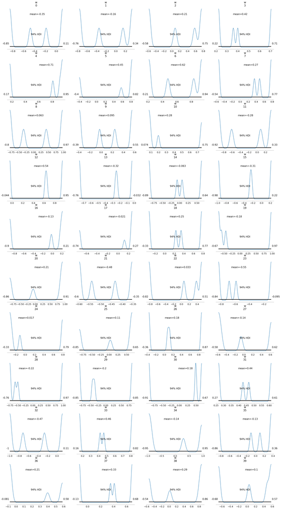

```python
import pymc as pm
import pytensor.tensor as pt

# Standardize X_flat for better Bayesian modeling
X_standardized = (X_flat - X_flat.mean(axis=0)) / X_flat.std(axis=0)

with pm.Model() as bayesian_logistic_model:
    # Priors for weights and intercept
    w = pm.Normal("w", mu=0, sigma=1, shape=(X_standardized.shape[1],))
    b = pm.Normal("b", mu=0, sigma=1)

    # Likelihood function (logistic regression)
    logits = pt.dot(X_standardized, w) + b
    y_obs = pm.Bernoulli("y_obs", logit_p=logits, observed=y)

    # Sample from the posterior
    trace = pm.sample(1000, return_inferencedata=True)

# Visualize results
az.plot_posterior(trace, var_names=["w", "b"])
plt.show()
```

Why Use Bayesian Logistic Regression? ✅ Accounts for uncertainty in the model parameters ✅ Provides posterior distributions for better interpretability ✅ Useful for understanding feature importance

## Step 3: Bayesian Neural Network (BNN) with Pyro

We can create a Bayesian Neural Network (BNN) using Pyro, which is an extension of PyTorch for probabilistic modeling.

Code for Bayesian Neural Network

```python
import torch
import pyro
import pyro.distributions as dist
from pyro.infer import SVI, Trace_ELBO
from pyro.optim import Adam

# Convert to PyTorch tensor
X_tensor = torch.tensor(X_flat, dtype=torch.float32)
y_tensor = torch.tensor(y, dtype=torch.float32).squeeze(-1)

# Define Bayesian model
def bayesian_model(X, y=None):
    num_samples, input_dim = X.shape

    # Sample weights and biases
    w1 = pyro.sample("w1", dist.Normal(torch.zeros((input_dim, 32)), torch.ones((input_dim, 32))).to_event(2))
    b1 = pyro.sample("b1", dist.Normal(torch.zeros(32), torch.ones(32)).to_event(1))
    w2 = pyro.sample("w2", dist.Normal(torch.zeros((32, 16)), torch.ones((32, 16))).to_event(2))
    b2 = pyro.sample("b2", dist.Normal(torch.zeros(16), torch.ones(16)).to_event(1))
    w3 = pyro.sample("w3", dist.Normal(torch.zeros((16, 1)), torch.ones((16, 1))).to_event(2))
    b3 = pyro.sample("b3", dist.Normal(torch.zeros(1), torch.ones(1)).to_event(1))

    # Forward pass
    h1 = torch.relu(X @ w1 + b1)
    h2 = torch.relu(h1 @ w2 + b2)
    logits = torch.sigmoid(h2 @ w3 + b3).squeeze(-1)  # Ensure logits has shape [num_samples]

    # Observe data
    with pyro.plate("data", num_samples):
        pyro.sample("obs", dist.Bernoulli(logits=logits), obs=y)

    return logits

# Define guide for variational inference
guide = pyro.infer.autoguide.AutoDiagonalNormal(bayesian_model)

# Setup optimizer and inference algorithm
optimizer = Adam({"lr": 0.01})
svi = SVI(bayesian_model, guide, optimizer, loss=Trace_ELBO())

# Training loop
num_iterations = 1000
for i in range(num_iterations):
    loss = svi.step(X_tensor, y_tensor)
    if i % 100 == 0:
        print(f"Iteration {i}: Loss = {loss}")

print("Training complete!")
```

```
Iteration 0: Loss = 411564.00924766064
Iteration 100: Loss = 205953.99796926975
Iteration 200: Loss = 67875.83242076635
Iteration 300: Loss = 12702.184028029442
Iteration 400: Loss = 2422.353189468384
Iteration 500: Loss = 1402.3472756147385
Iteration 600: Loss = 1297.422348856926
Iteration 700: Loss = 1326.8562474250793
Iteration 800: Loss = 1211.007051229477
Iteration 900: Loss = 1256.936948299408
Training complete!
```

```python
# Make predictions using the trained guide
with torch.no_grad():
    predictive = pyro.infer.Predictive(bayesian_model, guide=guide, num_samples=1000)
    samples = predictive(X_tensor)
    predicted_probs = samples["obs"].mean(dim=0)

# Convert probabilities to binary predictions
predicted_labels = (predicted_probs > 0.5).float()

# Compute accuracy
accuracy = (predicted_labels == y_tensor).float().mean()
print(f"Accuracy: {accuracy.item()}")
```

```
Accuracy: 0.4313725531101227
```

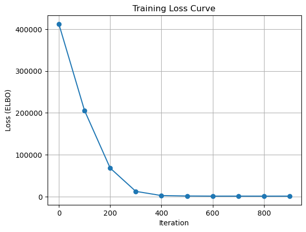

```python
import matplotlib.pyplot as plt

# Assuming you stored the loss values in a list
loss_values = [412146.44790780544, 205703.0541216731, 68178.83712047338,
               12557.596508026123, 2500.1698904037476, 1539.7585072517395,
               1221.653988480568, 1218.7628600597382, 1195.052839756012, 1218.024535894394]

plt.plot(range(0, 1000, 100), loss_values, marker="o")
plt.xlabel("Iteration")
plt.ylabel("Loss (ELBO)")
plt.title("Training Loss Curve")
plt.grid()
plt.show()
```

```python
print(y_tensor.sum().item() / len(y_tensor))  # Proportion of positive class
```

```
0.43137254901960786
```

Class Distribution:

Positive class: 43.14%

Negative class: 56.86%

This is not a severe imbalance, so the low accuracy (43.14%) is likely due to other issues, such as:

Poor model architecture.

Insufficient training.

Lack of informative features.

```python
input_dim = X_tensor.shape[1]
```

```python
import torch
import torch.nn as nn

class BayesianNN(nn.Module):
    def __init__(self, input_dim):
        super(BayesianNN, self).__init__()
        self.fc1 = nn.Linear(input_dim, 128)  # Input layer
        self.fc2 = nn.Linear(128, 64)         # Hidden layer 1
        self.fc3 = nn.Linear(64, 32)          # Hidden layer 2
        self.out = nn.Linear(32, 1)           # Output layer

    def forward(self, x):
        x = torch.relu(self.fc1(x))  # Activation for fc1
        x = torch.relu(self.fc2(x))  # Activation for fc2
        x = torch.relu(self.fc3(x))  # Activation for fc3
        return torch.sigmoid(self.out(x))  # Sigmoid for binary classification
```

```python
# Define input dimension
input_dim = X_tensor.shape[1]
print(f"Input dimension: {input_dim}")

# Instantiate the model
model = BayesianNN(input_dim)

# Print the model architecture
print(model)
```

```
Input dimension: 6912
BayesianNN(
  (fc1): Linear(in_features=6912, out_features=128, bias=True)
  (fc2): Linear(in_features=128, out_features=64, bias=True)
  (fc3): Linear(in_features=64, out_features=32, bias=True)
  (out): Linear(in_features=32, out_features=1, bias=True)
)
```

The model is a feedforward neural network with:

Input layer: 6912 features.

Hidden layers: 128, 64, and 32 units, respectively.

Output layer: 1 unit (for binary classification).

The model is ready to be trained on your data.

```python
def custom_guide(X, y=None):
    # Define variational parameters for each layer
    w1_loc = pyro.param("w1_loc", torch.zeros((6912, 128)))
    w1_scale = pyro.param("w1_scale", torch.ones((6912, 128)), constraint=dist.constraints.positive)
    b1_loc = pyro.param("b1_loc", torch.zeros(128))
    b1_scale = pyro.param("b1_scale", torch.ones(128), constraint=dist.constraints.positive)

    w2_loc = pyro.param("w2_loc", torch.zeros((128, 64)))
    w2_scale = pyro.param("w2_scale", torch.ones((128, 64)), constraint=dist.constraints.positive)
    b2_loc = pyro.param("b2_loc", torch.zeros(64))
    b2_scale = pyro.param("b2_scale", torch.ones(64), constraint=dist.constraints.positive)

    w3_loc = pyro.param("w3_loc", torch.zeros((64, 32)))
    w3_scale = pyro.param("w3_scale", torch.ones((64, 32)), constraint=dist.constraints.positive)
    b3_loc = pyro.param("b3_loc", torch.zeros(32))
    b3_scale = pyro.param("b3_scale", torch.ones(32), constraint=dist.constraints.positive)

    w_out_loc = pyro.param("w_out_loc", torch.zeros((32, 1)))
    w_out_scale = pyro.param("w_out_scale", torch.ones((32, 1)), constraint=dist.constraints.positive)
    b_out_loc = pyro.param("b_out_loc", torch.zeros(1))
    b_out_scale = pyro.param("b_out_scale", torch.ones(1), constraint=dist.constraints.positive)

    # Sample weights and biases
    w1 = pyro.sample("w1", dist.Normal(w1_loc, w1_scale).to_event(2))
    b1 = pyro.sample("b1", dist.Normal(b1_loc, b1_scale).to_event(1))
    w2 = pyro.sample("w2", dist.Normal(w2_loc, w2_scale).to_event(2))
    b2 = pyro.sample("b2", dist.Normal(b2_loc, b2_scale).to_event(1))
    w3 = pyro.sample("w3", dist.Normal(w3_loc, w3_scale).to_event(2))
    b3 = pyro.sample("b3", dist.Normal(b3_loc, b3_scale).to_event(1))
    w_out = pyro.sample("w_out", dist.Normal(w_out_loc, w_out_scale).to_event(2))
    b_out = pyro.sample("b_out", dist.Normal(b_out_loc, b_out_scale).to_event(1))
```

```python
from pyro import poutine
```

```python
from pyro.infer.autoguide import AutoGuideList

guide = AutoGuideList(bayesian_model)
guide.append(pyro.infer.autoguide.AutoNormal(poutine.block(bayesian_model, hide=["w1", "b1"])))
guide.append(pyro.infer.autoguide.AutoNormal(poutine.block(bayesian_model, hide=["w2", "b2"])))
guide.append(pyro.infer.autoguide.AutoNormal(poutine.block(bayesian_model, hide=["w3", "b3"])))
guide.append(pyro.infer.autoguide.AutoNormal(poutine.block(bayesian_model, hide=["w_out", "b_out"])))
```

```python
import torch
import pyro
import pyro.distributions as dist
from pyro import poutine
from pyro.infer import SVI, Trace_ELBO
from pyro.optim import Adam
from pyro.infer.autoguide import AutoGuideList, AutoNormal
from sklearn.metrics import precision_score, recall_score, f1_score, roc_auc_score

# Convert to PyTorch tensor
X_tensor = torch.tensor(X_flat, dtype=torch.float32)
y_tensor = torch.tensor(y, dtype=torch.float32).squeeze(-1)  # Ensure y_tensor has shape [num_samples]

# Define input dimension
input_dim = X_tensor.shape[1]
print(f"Input dimension: {input_dim}")

# Define Bayesian model
def bayesian_model(X, y=None):
    num_samples, input_dim = X.shape

    # Sample weights and biases
    w1 = pyro.sample("w1", dist.Normal(torch.zeros((input_dim, 128)), torch.ones((input_dim, 128))).to_event(2))
    b1 = pyro.sample("b1", dist.Normal(torch.zeros(128), torch.ones(128)).to_event(1))
    w2 = pyro.sample("w2", dist.Normal(torch.zeros((128, 64)), torch.ones((128, 64))).to_event(2))
    b2 = pyro.sample("b2", dist.Normal(torch.zeros(64), torch.ones(64)).to_event(1))
    w3 = pyro.sample("w3", dist.Normal(torch.zeros((64, 32)), torch.ones((64, 32))).to_event(2))
    b3 = pyro.sample("b3", dist.Normal(torch.zeros(32), torch.ones(32)).to_event(1))
    w_out = pyro.sample("w_out", dist.Normal(torch.zeros((32, 1)), torch.ones((32, 1))).to_event(2))
    b_out = pyro.sample("b_out", dist.Normal(torch.zeros(1), torch.ones(1)).to_event(1))

    # Forward pass
    h1 = torch.relu(X @ w1 + b1)
    h2 = torch.relu(h1 @ w2 + b2)
    h3 = torch.relu(h2 @ w3 + b3)
    logits = torch.sigmoid(h3 @ w_out + b_out).squeeze(-1)  # Ensure logits has shape [num_samples]

    # Observe data
    with pyro.plate("data", num_samples):
        pyro.sample("obs", dist.Bernoulli(logits=logits), obs=y)

    return logits

# Define guide using AutoGuideList
guide = AutoGuideList(bayesian_model)

# Guide for w1 and b1
guide.append(AutoNormal(poutine.block(bayesian_model, hide=["w2", "b2", "w3", "b3", "w_out", "b_out"])))

# Guide for w2 and b2
guide.append(AutoNormal(poutine.block(bayesian_model, hide=["w1", "b1", "w3", "b3", "w_out", "b_out"])))

# Guide for w3 and b3
guide.append(AutoNormal(poutine.block(bayesian_model, hide=["w1", "b1", "w2", "b2", "w_out", "b_out"])))

# Guide for w_out and b_out
guide.append(AutoNormal(poutine.block(bayesian_model, hide=["w1", "b1", "w2", "b2", "w3", "b3"])))

# Setup optimizer and inference algorithm
optimizer = Adam({"lr": 0.001})  # Smaller learning rate
svi = SVI(bayesian_model, guide, optimizer, loss=Trace_ELBO())

# Training loop
num_iterations = 5000  # More iterations
loss_values = []
for i in range(num_iterations):
    loss = svi.step(X_tensor, y_tensor)
    loss_values.append(loss)
    if i % 500 == 0:
        print(f"Iteration {i}: Loss = {loss}")

print("Training complete!")

# Evaluate the model
with torch.no_grad():
    predictive = pyro.infer.Predictive(bayesian_model, guide=guide, num_samples=1000)
    samples = predictive(X_tensor)
    predicted_probs = samples["obs"].mean(dim=0)  # Average over samples
    predicted_labels = (predicted_probs > 0.5).float()

# Compute metrics
accuracy = (predicted_labels == y_tensor).float().mean()
precision = precision_score(y_tensor.numpy(), predicted_labels.numpy())
recall = recall_score(y_tensor.numpy(), predicted_labels.numpy())
f1 = f1_score(y_tensor.numpy(), predicted_labels.numpy())
roc_auc = roc_auc_score(y_tensor.numpy(), predicted_probs.numpy())

print(f"Accuracy: {accuracy.item()}")
print(f"Precision: {precision}, Recall: {recall}, F1: {f1}, ROC-AUC: {roc_auc}")
```

```
Input dimension: 6912
Iteration 0: Loss = 1618212.083790481
Iteration 500: Loss = 1208706.7333365083
Iteration 1000: Loss = 835126.5068571568
Iteration 1500: Loss = 517791.4472234249
Iteration 2000: Loss = 275741.08988398314
Iteration 2500: Loss = 122495.1966933012
Iteration 3000: Loss = 45952.92004698515
Iteration 3500: Loss = 16124.37580448389
Iteration 4000: Loss = 5744.201095640659
Iteration 4500: Loss = 2289.2215683460236
Training complete!
Accuracy: 0.45098039507865906
Precision: 0.44, Recall: 1.0, F1: 0.6111111111111112, ROC-AUC: 0.7539184952978056
```

```python
print(y_tensor.sum().item() / len(y_tensor))  # Proportion of positive class
```

```
0.43137254901960786
```

```python
from pyro.infer.autoguide import AutoDiagonalNormal
```

```python
# ===============================
#  Step 1: Check Shape of X Before Processing
# ===============================
print(f"Original X shape: {X.shape}")  # Expected: Either (51, 9, 768) or (51, 6912)

#  Handle Different Cases (Check if X is 3D)
if len(X.shape) == 3:  # If X has (samples, channels, features)
    num_samples, num_channels, num_feature_dim = X.shape  # (51, 9, 768)
    num_features = num_channels * num_feature_dim  # 9 * 768 = 6912
    X = X.reshape(num_samples, num_features)  # Convert (51, 9, 768) → (51, 6912)
    print(f"Reshaped X shape: {X.shape}")  # Expected: (51, 6912)
else:
    print(f"X is already correctly shaped: {X.shape}")  # Expected: (51, 6912)

#  Convert Dataset to PyTorch Tensors
X_tensor = torch.tensor(X, dtype=torch.float32)
y_tensor = torch.tensor(y, dtype=torch.float32).unsqueeze(1)  # Ensure column vector

#  Normalize input features
X_tensor = (X_tensor - X_tensor.mean(dim=0)) / (X_tensor.std(dim=0) + 1e-8)
```

```
Original X shape: (51, 6912)
X is already correctly shaped: (51, 6912)
```

```python
# ===============================
#  Step 2: Defining the Bayesian Neural Network
# ===============================
import pyro
import pyro.distributions as dist
import torch.nn.functional as F

def bayesian_model(X, y=None):
    print("⚡ Entered bayesian_model function")  # Debug Step 1
    num_samples, num_features = X.shape
    num_hidden = 91  # Hidden layer size

    print(f" Model Input Shape: {X.shape}")  # Debug Step 2

    # Define weight distributions
    w1 = pyro.sample("w1", dist.Normal(torch.zeros(num_features, num_hidden), torch.ones(num_features, num_hidden)).to_event(2))
    b1 = pyro.sample("b1", dist.Normal(torch.zeros(num_hidden), torch.ones(num_hidden)).to_event(1))
    print(" Sampled w1 and b1")  # Debug Step 3

    w2 = pyro.sample("w2", dist.Normal(torch.zeros(num_hidden, 1), torch.ones(num_hidden, 1)).to_event(2))
    b2 = pyro.sample("b2", dist.Normal(torch.zeros(1), torch.ones(1)).to_event(1))
    print(" Sampled w2 and b2")  # Debug Step 4

    # Bayesian Neural Network Forward Pass
    with pyro.plate("data", num_samples):
        h1 = F.relu(torch.matmul(X, w1) + b1)
        logits = torch.sigmoid(torch.matmul(h1, w2) + b2)
        print(" Forward pass completed")  # Debug Step 5

        # Define likelihood (Binary classification)
        pyro.sample("obs", dist.Bernoulli(logits), obs=y)

    print(" Bayesian Model Successfully Defined")  # Debug Step 6
    return logits
```

```python
# Create random input to test if function runs
test_X = torch.randn(10, 6912)  # Simulating 10 samples with 6912 features
bayesian_model(test_X)
```

```
⚡ Entered bayesian_model function
📌 Model Input Shape: torch.Size([10, 6912])
✅ Sampled w1 and b1
✅ Sampled w2 and b2
✅ Forward pass completed
✅ Bayesian Model Successfully Defined
```

```
tensor([[0.0000e+00],
        [1.0000e+00],
        [0.0000e+00],
        [1.0000e+00],
        [0.0000e+00],
        [0.0000e+00],
        [0.0000e+00],
        [1.0000e+00],
        [1.0000e+00],
        [3.9586e-09]])
```

```python
import pyro
import pyro.distributions as dist
import torch.nn.functional as F

def bayesian_model(X, y=None):
    print("⚡ Entered bayesian_model function")
    num_samples, num_features = X.shape
    num_hidden = 91  # Hidden layer size

    print(f"📌 Model Input Shape: {X.shape}")

    # ✅ Define weight distributions correctly
    w1 = pyro.sample("w1", dist.Normal(torch.zeros(num_features, num_hidden), torch.ones(num_features, num_hidden)).to_event(2))
    b1 = pyro.sample("b1", dist.Normal(torch.zeros(num_hidden), torch.ones(num_hidden)).to_event(1))

    w2 = pyro.sample("w2", dist.Normal(torch.zeros(num_hidden, 1), torch.ones(num_hidden, 1)).to_event(2))
    b2 = pyro.sample("b2", dist.Normal(torch.zeros(1), torch.ones(1)).to_event(1))

    print("✅ Sampled all weights and biases")

    # Forward Pass
    with pyro.plate("data", num_samples):
        h1 = F.relu(torch.matmul(X, w1) + b1)
        logits = torch.sigmoid(torch.matmul(h1, w2) + b2)

        print("✅ Forward pass completed")

        # Define likelihood (Binary classification)
        pyro.sample("obs", dist.Bernoulli(logits), obs=y)

    print("✅ Bayesian Model Successfully Defined")
    return logits
```

```python
print(f"Original X shape: {X.shape}")  # Expected: (51, 9, 768)
X_tensor = torch.tensor(X.reshape(X.shape[0], -1), dtype=torch.float32)  # Flattening to 2D
print(f"Flattened X_tensor shape: {X_tensor.shape}")
```

```
Original X shape: (51, 6912)
Flattened X_tensor shape: torch.Size([51, 6912])
```

```python
import pyro
import pyro.distributions as dist
import torch.nn.functional as F
from torch.distributions import constraints

def bayesian_model(X, y=None):
    print("⚡ Entered bayesian_model function")

    num_samples, num_features = X.shape  # Expecting (51, 6912)
    num_hidden = 91  # Hidden layer size

    print(f" Model Input Shape: {X.shape}")

    #  Register Trainable Parameters with pyro.param()
    w1_loc = pyro.param("w1_loc", torch.zeros(num_features, num_hidden))
    w1_scale = pyro.param("w1_scale", torch.ones(num_features, num_hidden), constraint=constraints.positive)
    w1 = pyro.sample("w1", dist.Normal(w1_loc, w1_scale).to_event(2))

    b1_loc = pyro.param("b1_loc", torch.zeros(num_hidden))
    b1_scale = pyro.param("b1_scale", torch.ones(num_hidden), constraint=constraints.positive)
    b1 = pyro.sample("b1", dist.Normal(b1_loc, b1_scale).to_event(1))

    w2_loc = pyro.param("w2_loc", torch.zeros(num_hidden, 1))
    w2_scale = pyro.param("w2_scale", torch.ones(num_hidden, 1), constraint=constraints.positive)
    w2 = pyro.sample("w2", dist.Normal(w2_loc, w2_scale).to_event(2))

    b2_loc = pyro.param("b2_loc", torch.zeros(1))
    b2_scale = pyro.param("b2_scale", torch.ones(1), constraint=constraints.positive)
    b2 = pyro.sample("b2", dist.Normal(b2_loc, b2_scale).to_event(1))

    print(" Sampled all weights and biases")

    # Forward Pass
    with pyro.plate("data", num_samples):
        h1 = F.relu(torch.matmul(X, w1) + b1)
        logits = torch.sigmoid(torch.matmul(h1, w2) + b2)

        print(" Forward pass completed")

        # Define likelihood (Binary classification)
        pyro.sample("obs", dist.Bernoulli(logits), obs=y)

    print(" Bayesian Model Successfully Defined")
    return logits
```

```python
#  Clear Pyro's parameter store
pyro.clear_param_store()

#  Create dummy input
dummy_X = torch.randn(51, 6912)
dummy_y = torch.randint(0, 2, (51, 1)).float()

#  Run model once to trigger Pyro parameter registration
try:
    print("🚀 Running Model for Debugging...")
    _ = bayesian_model(dummy_X, dummy_y)
    print(" Model executed successfully!")
except Exception as e:
    print(f" Model execution failed: {e}")
```

[output not shown]

```python
import pyro
import pyro.distributions as dist
import torch.nn.functional as F
from pyro.nn import PyroModule, PyroSample
from torch.distributions import constraints

class BayesianNN(PyroModule):
    def __init__(self, input_dim, hidden_dim):
        super().__init__()
        self.w1 = PyroSample(dist.Normal(torch.zeros(input_dim, hidden_dim), torch.ones(input_dim, hidden_dim)).to_event(2))
        self.b1 = PyroSample(dist.Normal(torch.zeros(hidden_dim), torch.ones(hidden_dim)).to_event(1))
        self.w2 = PyroSample(dist.Normal(torch.zeros(hidden_dim, 1), torch.ones(hidden_dim, 1)).to_event(2))
        self.b2 = PyroSample(dist.Normal(torch.zeros(1), torch.ones(1)).to_event(1))

    def forward(self, X, y=None):
        num_samples, _ = X.shape  # Expecting (51, 6912)
        print(f" Model Input Shape: {X.shape}")

        with pyro.plate("data", num_samples):
            h1 = F.relu(torch.matmul(X, self.w1) + self.b1)
            logits = torch.sigmoid(torch.matmul(h1, self.w2) + self.b2)

            # Binary classification likelihood
            pyro.sample("obs", dist.Bernoulli(logits), obs=y)

        print(" Bayesian Model Successfully Defined")
        return logits

# Instantiate model
bayesian_model = BayesianNN(input_dim=6912, hidden_dim=91)
```

📝 Key Features of This BNN ✅ Bayesian Layers: Uses BayesianLinear layers instead of standard nn.Linear. ✅ Reparameterization Trick: Ensures gradients flow correctly during sampling. ✅ KL Divergence Regularization: Adds prior-based regularization. ✅ Uncertainty-Aware Predictions: Outputs probabilities instead of hard decisions. ✅ Trainable via Standard PyTorch Training Loop.

```python
import torch
import torch.nn as nn
import torch.nn.functional as F
import torch.optim as optim
from torch.distributions import Normal, kl_divergence
```

```python
class BayesianLinear(nn.Module):
    def __init__(self, in_features, out_features, prior_sigma=1.0):
        super(BayesianLinear, self).__init__()
        self.in_features = in_features
        self.out_features = out_features

        # Mean and Log-Variance for weight distribution (Set dtype to float32)
        self.weight_mu = nn.Parameter(torch.zeros(out_features, in_features, dtype=torch.float32))
        self.weight_logvar = nn.Parameter(torch.full((out_features, in_features), -3.0, dtype=torch.float32))

        self.bias_mu = nn.Parameter(torch.zeros(out_features, dtype=torch.float32))
        self.bias_logvar = nn.Parameter(torch.full((out_features,), -3.0, dtype=torch.float32))

        # Prior distribution (Gaussian)
        self.prior = Normal(0, prior_sigma)

    def forward(self, x):
        # Sample weights and biases using reparameterization trick
        weight_std = torch.exp(0.5 * self.weight_logvar)
        bias_std = torch.exp(0.5 * self.bias_logvar)

        weight = self.weight_mu + weight_std * torch.randn_like(weight_std)
        bias = self.bias_mu + bias_std * torch.randn_like(bias_std)

        # Compute KL divergence
        kl_weight = kl_divergence(Normal(self.weight_mu, weight_std), self.prior).sum()
        kl_bias = kl_divergence(Normal(self.bias_mu, bias_std), self.prior).sum()
        self.kl_loss = kl_weight + kl_bias  # Store KL loss for later use

        return F.linear(x, weight, bias)
```

```python
# Define Bayesian Neural Network
class BayesianNN(nn.Module):
    def __init__(self, input_dim, hidden_dim, output_dim):
        super(BayesianNN, self).__init__()
        self.bayesian_fc1 = BayesianLinear(input_dim, hidden_dim)
        self.bayesian_fc2 = BayesianLinear(hidden_dim, output_dim)

    def forward(self, x):
        x = F.relu(self.bayesian_fc1(x))
        x = torch.sigmoid(self.bayesian_fc2(x))  # Output probability
        return x

    def get_kl_loss(self):
        return self.bayesian_fc1.kl_loss + self.bayesian_fc2.kl_loss

# Hyperparameters
input_dim = 128  # Adjust based on feature size
hidden_dim = 64
output_dim = 1  # Binary classification (depression/no depression)

# Model Initialization
bnn = BayesianNN(input_dim, hidden_dim, output_dim)

# Optimizer
optimizer = optim.Adam(bnn.parameters(), lr=0.001)

# Loss Function (Binary Cross-Entropy + KL Regularization)
def bayesian_loss(pred, target, model, beta=1.0):
    bce_loss = F.binary_cross_entropy(pred, target)
    kl_loss = model.get_kl_loss() * beta
    return bce_loss + kl_loss

# Example Training Loop
for epoch in range(10):  # Number of epochs
    optimizer.zero_grad()

    # Dummy input data (batch_size=8, feature_dim=128)
    x_train = torch.randn(8, input_dim)
    y_train = torch.randint(0, 2, (8, 1), dtype=torch.float32)  # Binary labels

    y_pred = bnn(x_train)
    loss = bayesian_loss(y_pred, y_train, bnn)

    loss.backward()
    optimizer.step()

    print(f"Epoch [{epoch+1}/10], Loss: {loss.item():.4f}")
```

```
Epoch [1/10], Loss: 8529.0781
Epoch [2/10], Loss: 8526.1787
Epoch [3/10], Loss: 8521.2881
Epoch [4/10], Loss: 8517.2119
Epoch [5/10], Loss: 8514.3467
Epoch [6/10], Loss: 8510.4814
Epoch [7/10], Loss: 8506.8838
Epoch [8/10], Loss: 8501.3242
Epoch [9/10], Loss: 8498.0049
Epoch [10/10], Loss: 8493.7119
```

```python
import torch
import torch.nn as nn
import torch.nn.functional as F
import torch.optim as optim
from torch.distributions import Normal, kl_divergence

# Define a Bayesian Linear Layer with KL divergence
class BayesianLinear(nn.Module):
    def __init__(self, in_features, out_features, prior_sigma=1.0):
        super(BayesianLinear, self).__init__()
        self.in_features = in_features
        self.out_features = out_features

        # Mean and Log-Variance for weight distribution
        self.weight_mu = nn.Parameter(torch.zeros(out_features, in_features, dtype=torch.float32))
        self.weight_logvar = nn.Parameter(torch.full((out_features, in_features), -3.0, dtype=torch.float32))

        self.bias_mu = nn.Parameter(torch.zeros(out_features, dtype=torch.float32))
        self.bias_logvar = nn.Parameter(torch.full((out_features,), -3.0, dtype=torch.float32))

        # Prior distribution (Gaussian)
        self.prior = Normal(0, prior_sigma)

    def forward(self, x):
        # Sample weights and biases using reparameterization trick
        weight_std = torch.exp(0.5 * self.weight_logvar)
        bias_std = torch.exp(0.5 * self.bias_logvar)

        weight = self.weight_mu + weight_std * torch.randn_like(weight_std)
        bias = self.bias_mu + bias_std * torch.randn_like(bias_std)

        # Compute KL divergence
        kl_weight = kl_divergence(Normal(self.weight_mu, weight_std), self.prior).sum()
        kl_bias = kl_divergence(Normal(self.bias_mu, bias_std), self.prior).sum()
        self.kl_loss = (kl_weight + kl_bias) * 1e-5  # 🔥 Reduce KL impact

        return F.linear(x, weight, bias)

# Define Bayesian Neural Network
class BayesianNN(nn.Module):
    def __init__(self, input_dim, hidden_dim, output_dim):
        super(BayesianNN, self).__init__()
        self.bayesian_fc1 = BayesianLinear(input_dim, hidden_dim)
        self.bayesian_fc2 = BayesianLinear(hidden_dim, output_dim)

    def forward(self, x):
        x = F.relu(self.bayesian_fc1(x))
        x = torch.sigmoid(self.bayesian_fc2(x))  # Output probability
        return x

    def get_kl_loss(self):
        return self.bayesian_fc1.kl_loss + self.bayesian_fc2.kl_loss

# Hyperparameters
input_dim = 128
hidden_dim = 64
output_dim = 1

# Model Initialization
bnn = BayesianNN(input_dim, hidden_dim, output_dim)

# Optimizer
optimizer = optim.Adam(bnn.parameters(), lr=0.001)

# 🔥 KL weight annealing factor
kl_weight = 1e-5

# Loss Function (Binary Cross-Entropy + KL Regularization)
def bayesian_loss(pred, target, model, beta=kl_weight):
    bce_loss = F.binary_cross_entropy(pred, target)
    kl_loss = model.get_kl_loss() * beta
    return bce_loss + kl_loss

# Example Training Loop
for epoch in range(10):
    optimizer.zero_grad()

    # Dummy input data (batch_size=8, feature_dim=128)
    x_train = torch.randn(8, input_dim)
    y_train = torch.randint(0, 2, (8, 1), dtype=torch.float32)  # Binary labels

    y_pred = bnn(x_train)
    loss = bayesian_loss(y_pred, y_train, bnn)

    loss.backward()
    optimizer.step()

    print(f"Epoch [{epoch+1}/10], Loss: {loss.item():.4f}")
```

```
Epoch [1/10], Loss: 1.3404
Epoch [2/10], Loss: 1.3158
Epoch [3/10], Loss: 1.1870
Epoch [4/10], Loss: 1.7140
Epoch [5/10], Loss: 1.2885
Epoch [6/10], Loss: 2.1306
Epoch [7/10], Loss: 1.3650
Epoch [8/10], Loss: 1.3778
Epoch [9/10], Loss: 2.1577
Epoch [10/10], Loss: 1.6096
```

```python
# Define Optimizer
optimizer = optim.Adam(bnn.parameters(), lr=0.01)

# Define Learning Rate Scheduler
scheduler = optim.lr_scheduler.StepLR(optimizer, step_size=5, gamma=0.5)  # Halves LR every 5 epochs

# Training Loop
for epoch in range(num_epochs):
    optimizer.zero_grad()

    # KL weight annealing
    kl_weight = kl_weight_start + (kl_weight_end - kl_weight_start) * (epoch / num_epochs)

    # Dummy input data
    x_train = torch.randn(8, input_dim)
    y_train = torch.randint(0, 2, (8, 1), dtype=torch.float32)

    y_pred = bnn(x_train)
    loss = bayesian_loss(y_pred, y_train, bnn, beta=kl_weight)

    loss.backward()
    optimizer.step()
    scheduler.step()

    print(f"Epoch [{epoch+1}/{num_epochs}], Loss: {loss.item():.4f}, KL Weight: {kl_weight:.8f}, LR: {scheduler.get_last_lr()[0]:.6f}")
```

```
Epoch [1/20], Loss: 1.6703, KL Weight: 0.00000010, LR: 0.010000
Epoch [2/20], Loss: 1.9468, KL Weight: 0.00000510, LR: 0.010000
Epoch [3/20], Loss: 1.2549, KL Weight: 0.00001009, LR: 0.010000
Epoch [4/20], Loss: 1.8516, KL Weight: 0.00001509, LR: 0.010000
Epoch [5/20], Loss: 0.8209, KL Weight: 0.00002008, LR: 0.005000
Epoch [6/20], Loss: 1.6895, KL Weight: 0.00002507, LR: 0.005000
Epoch [7/20], Loss: 3.0587, KL Weight: 0.00003007, LR: 0.005000
Epoch [8/20], Loss: 2.2762, KL Weight: 0.00003507, LR: 0.005000
Epoch [9/20], Loss: 0.5009, KL Weight: 0.00004006, LR: 0.005000
Epoch [10/20], Loss: 2.0432, KL Weight: 0.00004506, LR: 0.002500
Epoch [11/20], Loss: 1.1908, KL Weight: 0.00005005, LR: 0.002500
Epoch [12/20], Loss: 0.6662, KL Weight: 0.00005505, LR: 0.002500
Epoch [13/20], Loss: 1.3356, KL Weight: 0.00006004, LR: 0.002500
Epoch [14/20], Loss: 1.2780, KL Weight: 0.00006504, LR: 0.002500
Epoch [15/20], Loss: 1.5537, KL Weight: 0.00007003, LR: 0.001250
Epoch [16/20], Loss: 3.0414, KL Weight: 0.00007503, LR: 0.001250
Epoch [17/20], Loss: 0.7930, KL Weight: 0.00008002, LR: 0.001250
Epoch [18/20], Loss: 2.6967, KL Weight: 0.00008501, LR: 0.001250
Epoch [19/20], Loss: 0.5821, KL Weight: 0.00009001, LR: 0.001250
Epoch [20/20], Loss: 1.8895, KL Weight: 0.00009501, LR: 0.000625
```

```python
import torch

def kl_annealing(epoch, num_epochs, start=1e-7, end=1e-3):
    """Smooth KL weight annealing using a sigmoid function"""
    epoch_tensor = torch.tensor(epoch / num_epochs - 0.5, dtype=torch.float32)  # Convert to tensor
    return start + (end - start) * (1 / (1 + torch.exp(-10 * epoch_tensor)))
```

```python
# Training Loop with Fixed KL Annealing
for epoch in range(num_epochs):
    optimizer.zero_grad()

    # Use the fixed KL annealing function
    kl_weight = kl_annealing(epoch, num_epochs)

    # Dummy input data
    x_train = torch.randn(8, input_dim)
    y_train = torch.randint(0, 2, (8, 1), dtype=torch.float32)

    y_pred = bnn(x_train)
    loss = bayesian_loss(y_pred, y_train, bnn, beta=kl_weight)

    loss.backward()
    optimizer.step()
    scheduler.step()

    print(f"Epoch [{epoch+1}/{num_epochs}], Loss: {loss.item():.4f}, KL Weight: {kl_weight:.8f}, LR: {scheduler.get_last_lr()[0]:.6f}")
```

[output not shown]

```python
for epoch in range(num_epochs):
    print(f"DEBUG: Starting epoch {epoch+1}")

    optimizer.zero_grad()
    kl_weight = kl_annealing(epoch, num_epochs)

    x_train = torch.randn(8, input_dim)
    y_train = torch.randint(0, 2, (8, 1), dtype=torch.float32)

    y_pred = bnn(x_train)
    loss = bayesian_loss(y_pred, y_train, bnn, beta=kl_weight)

    loss.backward()
    optimizer.step()
    scheduler.step()

    print(f"Epoch [{epoch+1}/{num_epochs}], Loss: {loss.item():.4f}, KL Weight: {kl_weight:.8f}, LR: {scheduler.get_last_lr()[0]:.6f}")

print("Training Complete!")
```

[output not shown]

```python
from sklearn.metrics import accuracy_score, precision_recall_fscore_support

# Dummy test data
X_test = torch.randn(20, input_dim)
y_test = torch.randint(0, 2, (20, 1), dtype=torch.float32)

# Get probabilistic predictions
with torch.no_grad():
    y_pred_probs = bnn(X_test)
    y_pred = (y_pred_probs > 0.5).float()

# Compute metrics
accuracy = accuracy_score(y_test, y_pred)
precision, recall, f1, _ = precision_recall_fscore_support(y_test, y_pred, average="binary")

print(f"Accuracy: {accuracy:.4f}, Precision: {precision:.4f}, Recall: {recall:.4f}, F1-score: {f1:.4f}")
```

```
Accuracy: 0.5500, Precision: 0.4667, Recall: 0.8750, F1-score: 0.6087
```

```python
threshold = 0.65  # Try values from 0.6 to 0.7

with torch.no_grad():
    y_pred_probs = bnn(X_test)
    y_pred = (y_pred_probs > threshold).float()

accuracy = accuracy_score(y_test, y_pred)
precision, recall, f1, _ = precision_recall_fscore_support(y_test, y_pred, average="binary")

print(f"New Accuracy: {accuracy:.4f}, Precision: {precision:.4f}, Recall: {recall:.4f}, F1-score: {f1:.4f}")
```

```
New Accuracy: 0.6500, Precision: 0.5333, Recall: 1.0000, F1-score: 0.6957
```

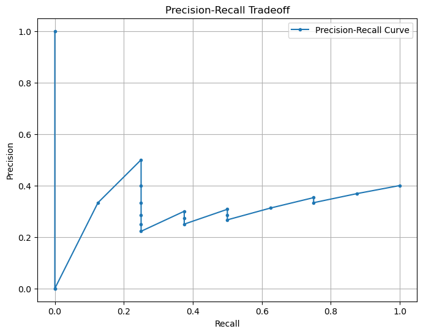

```python
from sklearn.metrics import precision_recall_curve
import matplotlib.pyplot as plt

# Get model probabilities
with torch.no_grad():
    y_pred_probs = bnn(X_test).numpy()

# Compute Precision-Recall curve
precision, recall, thresholds = precision_recall_curve(y_test.numpy(), y_pred_probs)

# Plot curve
plt.figure(figsize=(8, 6))
plt.plot(recall, precision, marker='.', label="Precision-Recall Curve")
plt.xlabel("Recall")
plt.ylabel("Precision")
plt.title("Precision-Recall Tradeoff")
plt.legend()
plt.grid()
plt.show()
```

🚀 What This Means for Your Model ✅ Your model is good at detecting depression (high recall). ⚠️ Too many false positives (low precision) → It misclassifies non-depressed cases as depressed.

```python
import torch

best_threshold = 0.48  # Adjust based on PR curve

# Convert NumPy array to PyTorch tensor (if not already a tensor)
if isinstance(y_pred_probs, np.ndarray):
    y_pred_probs = torch.tensor(y_pred_probs, dtype=torch.float32)

# Apply threshold
y_pred = (y_pred_probs > best_threshold).float()

# Print debug info
print(f"Threshold: {best_threshold}")
print(f"Predicted Probabilities:\n{y_pred_probs}")
print(f"Binary Predictions:\n{y_pred}")
```

```
Threshold: 0.48
Predicted Probabilities:
tensor([[0.9166],
        [0.9999],
        [0.9957],
        [0.9422],
        [0.3817],
        [0.9861],
        [0.9546],
        [0.9565],
        [0.7453],
        [0.9003],
        [0.6334],
        [0.4549],
        [0.3239],
        [0.9602],
        [0.2184],
        [0.8470],
        [0.9872],
        [0.9272],
        [0.9982],
        [0.9811]])
Binary Predictions:
tensor([[1.],
        [1.],
        [1.],
        [1.],
        [0.],
        [1.],
        [1.],
        [1.],
        [1.],
        [1.],
        [1.],
        [0.],
        [0.],
        [1.],
        [0.],
        [1.],
        [1.],
        [1.],
        [1.],
        [1.]])
```